# 02_Analysis

# 3. Computation of Document Similarity (Doc-to-Vec and Cosine Similarity Approach)

## 3.1. Data Pre-Process

One of our hypothesis is that poor performing companies will have less readable reports than those companies that perform(ed) well in the period of report. We argue that, if managers are trying to hide their poor performance, than they will also write reports that are not consistent/ similar over time, as otherwise investors would get familiar with the type of writing of the manager and be able to understand the "hidden" nuances. Thus, we control in the regression analysis (in section 5) for document similarity between reports of the same company. We will be using the so called cosine similarity, hypothesis will link company performance and cost of debt with the "readability" of their reports. We argue that the GFI will have an interaction with the document similary as an index to assess similarity of the MD&A of company $i$ between year $t$ and $t-1$.

In order to be able to compute the cosine similarity, we need to come up with a numerical vector representation of the text. For this regard, we will train a `doc2vec` model. Other than vectors representation like bag of words vectorizes the words as having the same distance in the vector space, such that phrases containing different meanings will have the same vector representation, given that the same words are used (e.g. "dog chases cat" and "cat chases dog"). `doctovec` on the other hand is capable of learning which words belong together of capturing semantics in the texts, such that similar documents will be close in the vector space. (More about the model can be found [here](https://arxiv.org/pdf/1405.4053.pdf).

We first build a model, assess it and then compute the cosine similarity between the documents in a later stage. We will start by reading in all items 7 for the companies stored in our directory and then keep only the files belong to the 394 companies that we kept in the dataset so far.

```python
preprocess = PreProcessor(directory = corpus_dir, item = 'item_7')
df_7Raw = preprocess.return_raw_item()
```

```python
# create a cik column
df_7Raw['cik'] = df_7Raw.file_name.str.split('_').str.get(0)
```

Again, we will keep only the files for the companies that are also found in the `Analysis_Ch2_Polarity.csv` dataset.

```python
# read in the polarity dataset
file_name = 'Analysis_Ch2_Polarity.csv'
df_pol = pd.read_csv(tables_dir + file_name, index_col = None, dtype = {'cik': str})
df_pol['cik'] = df_pol['cik'].str.zfill(10)
```

```python
df_7Raw = df_7Raw[df_7Raw['cik'].isin(df_pol['cik'].tolist())]
```

Next, we will do some cleaning on the item 7 contents in the 10-K files. We will reconstruct the text but remove digits, punctuations and special characters from it.

```python
# We create another function to paralize the process
def parallelize_cleantext(df, processes = os.cpu_count(), text_column = 'raw_text'):
    """
    Function is used to parallelize the clean_text function (below)
    """
    # copy the dataframe
    df = df.copy(deep = True)
    # get text column
    column_index = df.columns.get_loc(text_column)
    nlp = spacy.load("en_core_web_sm")
    def clean_text(file_info, remove_specialchar = True, lower_text = True, lemmatize = True, lower_case = True, remove_sw = True):
        """
        Function will return the cleaned text
        """
        index = file_info[0]
        text = file_info[1]
        #print(index, text)

        if remove_specialchar:
            #pass
            text = re.sub(r'[^A-Za-z0-9\s]', ' ', text)
        if lower_text:
            text = text.lower()


        tokens = word_tokenize(text)

        if remove_sw:
            non_stopwords = [word for word in tokens if word.lower() not in nltk.corpus.stopwords.words('english')]
            text = ' '.join(non_stopwords)

        return index, text
    # given a dataframe with the texts we will yield the text rowwiese
    def yield_row(df):
        for row in df.itertuples():
            index = row.Index
            text = row._asdict()[text_column]

            yield index, text

    gen = yield_row(df)

    with ProcessPool(processes = processes) as pool:
        results = list(tqdm(
            pool.imap(clean_text, gen), total = len(df), unit = 'it', desc = 'Cleaning text'
        ))


    for result in results:
        index, cleaned_text = result
        df.at[index, 'cleaned_text'] = cleaned_text

    return df
```

```python
df_7Cleaned = parallelize_cleantext(df_7Raw)
```

We will now further lemmatize the text.

```python
nlp = spacy.load('en_core_web_sm')
counter = 0
for row in tqdm(df_7Cleaned.itertuples(), desc = 'Lemmatizing text', total = df_7Cleaned.shape[0]):
    counter += 1
    doc = nlp(row._asdict()['cleaned_text'])
    lemmatized_text = ' '.join([token.lemma_ for token in doc])
    df_7Cleaned.at[row.Index, 'cleaned_text'] = lemmatized_text
```

```python
# We will now save this dataset
file_name = 'Analysis_Ch3_items7Cleaned_DocToVec.csv'
#df_7Cleaned.to_csv(tables + file_name, index = False)
# load dataset again
df_7Cleaned = pd.read_csv(tables + file_name, index_col = None, dtype = {'cik': str})
# reindex the dataframe
df_7Cleaned.reset_index(drop = True, inplace = True)
```

## 3.2. Training and Testing the Doc2Vec Model

In order to be able to train a doc2vec model, we need to tag the documents. Will create an ID for each of the companies in the dataset and we will create another column that will allow us to identify the year of each ID, these will serve us to be the tags of the documents.

```python
df_7Cleaned['ID'], _ = pd.factorize(df_7Cleaned['cik'])
df_7Cleaned['ID'] = df_7Cleaned['ID'].astype(str)
df_7Cleaned['FilingYear'] = '20' + df_7Cleaned.file_name.str.split('-').str.get(1)
df_7Cleaned['ID_FilingYear'] = df_7Cleaned['ID'] + '_' + df_7Cleaned['FilingYear']
```

Next, a function is created to tag and tokenize the documents in our dataframe.

```python
def tag_corpus(df, tokens_only = False, text_col = 'cleaned_text', id_col = 'ID_FilingYear'):
    df = df.copy(deep = True)
    text_index = df.columns.get_loc(text_col)
    id_index = df.columns.get_loc(id_col)

    for i in range(0, df.shape[0]):
        tokens = gensim.utils.simple_preprocess(df.iloc[i, text_index])
        if tokens_only:
            yield tokens
        else:
            # For training data, add tags
            yield gensim.models.doc2vec.TaggedDocument(tokens, [df.iloc[i, id_index]])
```

```python
train_corpus = list(tag_corpus(df_7Cleaned))
```

start by specifying the model and building its vocabulary (all unique token in the corpus)

```python
model = Doc2Vec(vector_size = 100, min_count = 2, epochs = 40)
model.build_vocab(train_corpus)
print(f"The vacabulary size is {len(model.wv.key_to_index)}.")
```

```
The vacabulary size is 26400.
```

the model training can start:

```python
%%time
model.train(train_corpus, total_examples = model.corpus_count, epochs = model.epochs)
```

```
CPU times: user 16min 51s, sys: 2.97 s, total: 16min 54s
Wall time: 5min 45s
```

We will now save this model we just trained:

```python
file_name = 'Analysis_Ch3_DocToVec.model'
#model.save(directories['models'] + file_name)
#print('Model saved!')
# load the model
model = Doc2Vec.load(directories['models'] + file_name)
```

[output not shown]

#### Assessing the Model

We will assess the model according to the description given in gensim's website. We use the same data we trained the model to infer the most the most similar vector. We expect that the most similar vector $i$ predicted by the model is the vector $i$ itself itself, and that the second most similar is not nearly as similar as the first one.

```python
ranks = []
second_ranks = []
for doc_id in tqdm(range(len(train_corpus)), desc='Ranking doc-similarity'):
    inferred_vector = model.infer_vector(train_corpus[doc_id].words)
    tag = train_corpus[doc_id].tags[0]
    sims = model.dv.most_similar([inferred_vector], topn = len(model.dv))
    rank = [docid for docid, sim in sims].index(tag)
    ranks.append(rank)
    second_ranks.append(sims[1])
```

We now check how for how many documents did the model correctly predict to be most similar with themselves (recall that we are doing in-sample assessment).

```python
import collections
counter = collections.Counter(ranks)
print('{} from a total of {} documents (say {}%) are found to be most similary with themselves'.format(counter[0],
                                                                                                       sum([value for value in counter.values()]),
                                                                                                       round(counter[0]/sum([value for value in counter.values()]) * 100, 2)))
```

```
3053 from a total of 3152 documents (say 96.86%) are found to be most similary with themselves
```

According to the tutorial in gensim's website, the similarity score should be as small as it can get for the document $j$ ranked second most similar to document $i$. Nevertheless, we argue that, as the documents come from the same company and companies tend to write similar report, the secod most similar document should also belong to the same company:

```python
import random
doc_id = random.randint(0, len(train_corpus) - 1)
tag = train_corpus[doc_id].tags
print('Train Document ({}): <<{}>>\n'.format(tag, ' '.join(train_corpus[doc_id].words)[:500]))
sim_id = second_ranks.index(second_ranks[doc_id])
print('Second Most Similar Document {}: <<{}>>\n'.format(second_ranks[doc_id], ' '.join(train_corpus[sim_id].words)[:500]))
```

```
Train Document (['161_2022']): <<item management discussion analysis financial condition result operation purpose management discussion analysis present information management believe relevant promote understand result operation cash flow fiscal year end december financial condition december read co…

Second Most Similar Document ('161_2023', 0.9689688682556152): <<item management discussion analysis financial condition result operation purpose management discussion analysis present information management believe relevant promote understand result operation cash flow fiscal year end december fina…
```

As we can see by the output above, the method turned out to be very useful, as the documents that are considered to be second in the rank of similarity normally belongs to the same company, but in different years. The ID is in the form *digit_year*, where the digit represents one company, and the year represents the filing-date of the 10-K report.

We could check for how much of the companies the files the most similar text found (excluding itself) belongs to the same company.

```python
comparison = [1 if tag[0].split('_')[0] == second_ranks[index][0].split('_')[0] else 0 for index, (_, tag) in enumerate(train_corpus)]
comparison = np.asarray(comparison)
print('The percentage of files that have another file of the same company as the second most similar is {}%'.format(comparison.mean()*100))
```

```
The percentage of files that have another file of the same company as the second most similar is 100.0%
```

We coded the list above as one if the second most similar text is one belonging to the same company and we see that this was the case for all the comapnies in the dataset.

Given the high-accuracy of the in-sample prediction, we will use these embeddings to compute cosine-similary of the item 7 in the 10-K files across years.

Now that we got embeddings for each management discussion in our corpus and calculate the similarity between them. We will create a function for that.

Given a tag we can get the document embedding from the model useing `model.dv[tag]`, we use scikit-lean function for cosine similarity in our function. Here is an example how to do it:

```python
cos_sim = cosine_similarity(model.dv['0_2023'].reshape(1, -1), model.dv['0_2016'].reshape(1, -1))

print('cosine similarity for text tagged 0_2023 and 0_2016 in our dataset: {}'.format(cos_sim[0][0]))
```

```
cosine similarity for text tagged 0_2023 and 0_2016 in our dataset: 0.8596512675285339
```

```python
def compute_similarity(df, model, id_col = 'ID_FilingYear'):
    """
    Function will return a matrix of cosine similiary for the companies in the dataset (similarity between their own 10-K files)
    Argument:
        df: a dataframe containing the tags used in the model.
        model: gensims doc2vec (trained) model
        id_col: the column in the dataframe containing the tags used in the doc2vec model
    """

    # get the id column as a list
    id_list = sorted(df[id_col].tolist())
    # now split all the values in this list using _ the left side is the company id
    # the right side is the year (we only want to have the year)
    years = [int(id.split('_')[1]) for id in id_list]

    # drop duplicates and sort the list
    years = sorted(list(set(years)))

    # now create a dataframe where the id_list are the index and the years are the columns
    df = pd.DataFrame(columns = years, index = id_list)


    # now we iterate over the company list and over the years
    for id in tqdm(id_list, desc = 'computing cos-similiarity'):
        for year in years:
            # create the tag
            comp_id = id.split('_')[0]
            tag = comp_id + '_' + str(year)
            # one of the tags is the same as the id
            cos_sim = cosine_similarity(model.dv[id].reshape(1, -1), model.dv[tag].reshape(1, -1))
            # now add the similarity score to the dataframe (recall that years are the columns and id are the indices)
            df.at[id, year] = cos_sim[0][0]

    # it is clear that in our dataset set there will be repetation, the similarity between a a file in 2016 with 2017 is the same
    # as the similarity of 2017 with 2017. The dataset is a wide format, we bring it to a long format
    df = df.reset_index().melt(id_vars = 'index', var_name = 'sim_ij', value_name = 'sim_t-1')
    # the index column will contain the former indices and the var_name column will contain the years
    # so sim index = 0_2016 and sim_ij = 2016 is the similarity of the document of company 0 with itself
    # we create an auxiliary column with a new index where we multiply the right side of the tag and the year, the product will be the same
    # for 2016 * 2017 and 2017 * 2016, so we can drop the repetitions
    df['aux'] = df['index'].str.split('_').str.get(1).astype(int) * df['sim_ij'].astype(int)
    df['aux'] = df['aux'].astype(str)
    df['aux'] = df['index'].str.split('_').str.get(0) + "_" + df['aux']
    df.drop_duplicates(subset = 'aux', keep = 'first', inplace = True)
    df.drop(columns = 'aux')
    # further we do not want to have the similarity of a file with each self,
    # and we only want to compute the similarity between file in period t and t-1
    # hence we can take the difference between the year of the index column and the sim_ij column
    # and keep only those values where teh difference is 1
    df['aux'] = df['index'].str.split('_').str.get(1).astype(int) - df['sim_ij'].astype(int)
    df = df[(df['aux'] == 1)]
    # we now drop the auxiliary column
    df.drop(columns = 'aux', inplace = True)
    # rename the index column to ID_FilingYear
    df.rename(columns = {'index': 'ID_FilingYear'}, inplace = True)
    return df
```

```python
df_similarity = compute_similarity(df_7Cleaned, model = model)
```

Similarity Score Distribution

Fig. 1.1.: *Figure displays the distribution of the cosine similarity between the MD&A section of the reports filed by company i in year t and t-1. The similarity score is a value between 0 and 1, being 1 most similar and 0 most dissimilar. As the illustrated by the picture, the great majority of the companies tend to be consistent in their MD&A-reports.*

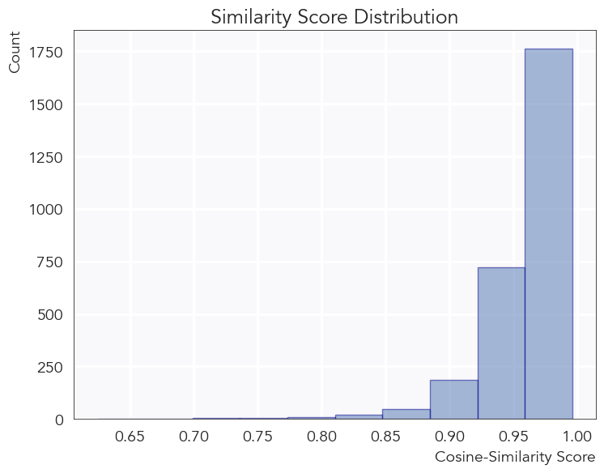

```python
sns.set_theme(rc={
    "axes.facecolor": (236/255, 236/255, 242/255, 0.3),
    "font.family": "Avenir", # change to Times New Roman to obtain the same font used in the paper
    "grid.linewidth": 2.2,
    "axes.edgecolor": "black",
    "axes.linewidth": 0.5,
    "font.weight": 'normal'
})

scale = 1.3
fig, ax = plt.subplots(figsize = (scale * 6.4, scale * 4.8))
df_similarity['sim_t-1'].hist(ax = ax, fill = 'darkblue', edgecolor = 'darkblue', alpha = 0.5)

ax.tick_params(labelsize = 14)
ax.set_title('Similarity Score Distribution', fontsize = 18);
ax.set_xlabel('Cosine-Similarity Score',  size = 14, loc = 'right')
ax.set_ylabel('Count', size = 14, loc = 'top')
#fig.savefig(fig_dir + 'Analysis_Ch3_SimiliartyScoreDist.png', bbox_inches = 'tight')
creator.tabDesc(
    title = 'Similarity Score Distribution',
    caption = 'Figure displays the distribution of the cosine similarity between the MD&A section of the reports filed by company i in year t and t-1. The similarity score is a value between 0 and 1, being 1 most similar and 0 most dissimilar. As the illustrated by the picture, the great majority of the companies tend to be consistent in their MD&A-reports.',
    cap_style = 'font-size:13px; text-align:justify;',
    type = 'Fig.',
    type_num = '1.1.',
    disp = True
)
```

Now recall that the `df_7Cleaned` and the `df_similirty` dataset have the a column in common, namely the `ID_FilingYear`. We will use this to get the 'cik' of the companies in order for us to be able to join the datasets in a later stage.

```python
df_similarity = pd.merge(df_similarity,df_7Cleaned[['ID_FilingYear', 'cik']], how = 'inner', on = 'ID_FilingYear')
```

Now we save the data-set to the disk.

```python
file_name = 'Analysis_Ch3_DocSimilarity.csv'
#df_similarity.to_csv(tables_dir + file_name, index = False)
```

In the next section we will turn our attention to computing the companies' Jensens Alpha.

# 4. Estimation of Companies' Jensens Alpha

Jensen's alpha is the amount of return that a company created above the one predicted by the systematic-risk adjusted return. It is namely the return that is attributed to the performance of the management of a company, as this return cannot be explained by the market. In order to compute Jensen's alpha we need first to calculate the company's beta (say systematic risk). Recall CAPM equation:

\begin{align} \mathbb{E}\left[r\right]=r_{F}+\beta\left(\mathbb{E}\left[r_{M}\right]-r_{F}\right) \end{align}

where:

- $r$: is the expected return of a given company
- $r_{F}$: is the risk-free rate of return (proxy is the US 10y bond yield)
- $r_{M}$: is the markt return (proxy is S&P500)
- $\beta_{i}$: is the company's systematic risk.

Jensen's alpha is the excess return of the company above what the market would expect:

\begin{align} \mathbb{E}\left[r\right]-r_{F}=\alpha_{jensen}+\beta_{i}\left(\mathbb{E}\left[r_{M}\right]-r_{F}\right) \end{align}

Recall that a company's beta measures the sensitivity of its returns with the one of the market and is defined as $\beta=\frac{\sigma_{r,r_{M}}}{\sigma_{r_{M}}^2}$. Defining $R_{i, t} = \mathbb{E}\left[r_{i}\right]-r_{F_{t}}$ to be the return of company $i$ (or market) above the risk-free rate at period $t$ with $t = 1, \dots, 52$ (assuming that the year has 52 weeks), Jensen's alpha and the company's beta could either be computed fitting linear regression model of the type for each company and each year in the data set:

\begin{align} R_{i,t}=\alpha_{jensen\left(i,t\right)}+\beta_{i} R_{M,t} + \varepsilon_{i,t}, \end{align}

or it can be computed manually as $\widehat{\alpha}_{jensen\left(i\right)} = \bar{R}_{i} - \widehat{\beta_{i}} \bar{R}_{M}$ once we know beta (where $\bar{R}_{j}\equiv \mu_{R_{j}}$ is the mean considering all t in a given year). We choose to obtain the beta from CapitalIQ. The reason is that we want to keep as many companies as possible in the data set. Notice that we indexed the risk free rate $r_{F_t}$ with time, meaning that we allow it to float (different than standard CAPM that assumes a fixed risk-free rate of return).

We will start by importing the datasets containing share log-returns at a weekly basis obtained from yahoo finance, the one containing the betas, also computed using 52-weeks according to Capital IQ, and the one containing the US-10y bond yield at constant maturity acquired from the US-Federal Reserve (of St. Louis) and aggregated at a weekly basis. According to information of CapitalIQ, for US-Companies, the market portfolio used to compute the betas is the S&P-500, and as all companies in our data set are american companies, choosing the S&P500 to calculate the Jensens Alpha is consistent with the betas.

Notice that, in order for us to obtain the beta in capital IQ, we need to pass a date which was always chosen to be the 12/31 of a given year (for further details on the data acquisition and aggregation of share prices, bond-yield and calculation of variance and returns, see `01_Scraper.ipynb`, Section 5).

```python
# import betas
df_betas = pd.read_csv(tables_dir + 'Scraper_Ch5_BetasFinal_Weekly.csv', index_col = None, dtype = {'cik': str})
# import prices
df_returns = pd.read_excel(tables_dir + 'Scraper_Ch5_SharePricesAndMoments.xlsx', sheet_name = 'log_return_weekly', index_col = 'Date') # Unnamed:0 is the date column

# we append an extra column in df_return to hold the bond yield.
df_rf = pd.read_csv(tables + 'Scraper_Ch5_WeeklyDGS10.csv', index_col = 'Date')
# convert index to date
df_returns.index = pd.to_datetime(df_returns.index)
df_rf.index = pd.to_datetime(df_rf.index)

# sort the indices
df_returns.sort_index(ascending = True, inplace = True)
df_rf.sort_index(ascending = True, inplace = True)

# create a dictionary to hold the new datasets
alpha_dict = {}
```

In order to compute Jensen's alpha, we only need the betas for the report year (beta_fiscal_year), but as the our hypothesis states that, given that past performance is poor (the one for the period of report), managers will hide information when the report the performance (in the filing year). Further, there are also two columns in the dataset named *Filing Date* and *Fiscal Date*. These columns were created to to query the information about the Betas in CapitalIQ-Addin at the end of those years. They do not relate to the date that a report was filed to the SEC (only their year are the same!).

We start by keeping only the information needed from the data set `df_betas`—*tickers*, *cik*, *beta_fiscal_year*, *Fiscal Date*— and by computing the weekly stock excess return (i.e. $R_{i,t} = r_{i,t} - r_{F_{t}}$) for each of the companies in the `df_retuns`.

```python
# keep only necessary information in the beta
df_betas = df_betas[['tickers','cik', 'beta_fiscal_year', 'Fiscal Date']]
```

we now take the difference between the `df_returns` and `df_rf` dataset in order to obtain $R_{i, t} = r_{i,t} - r_{F_{t}}$ for each one of the shares.

```python
# get columns of df_returns in a list
returns_columns = df_returns.columns.tolist()
# create a dataset with the same columns and index to store excess return
df_Ri = pd.DataFrame(index = df_returns.index, columns = returns_columns)

# now fill the dataset with values
for column in returns_columns:
    df_Ri[column] = df_returns[column].to_numpy() - df_rf['10y_yield'].to_numpy()
```

notice that we do not need all the excess-returns in the dataset, as this data set contains 415 companies plus the market portfolio. We know by now that we only kept 394 of those companies. Hence, we drop the columns with the tickers that will not be used. Recall that the dataset `Analysis_Ch2_Polarity.csv` contains among other things the ciks for these 394 companies and the `Scraper_Ch5_BetasFinal_Weekly.csv` contains tickers for 413 companies as well as their ciks. We can get the ciks that are common to both datasets in order to know which ticker to hold in the `df_Ri`.

```python
df_pol = pd.read_csv(tables_dir + 'Analysis_Ch2_Polarity.csv', dtype = {'cik': str})
df_pol['cik'] = df_pol['cik'].str.zfill(10)
tickers_to_keep = set(df_betas.set_index('cik').loc[[cik for cik in df_betas.drop_duplicates(subset = ['cik'])['cik'].tolist() if cik in df_pol['cik'].tolist()], 'tickers'].tolist() + ['^GSPC']) # add the market portolio to the list of tickers to be kept
```

```python
df_Ri = df_Ri[tickers_to_keep]
df_Ri.sort_index(axis = 1, inplace = True)
```

```python
# save the excess_return to the dictionary
alpha_dict['ri_minus_rf_weekly'] = df_Ri
creator.tabDesc(
    title = 'Excess Returns $R_{i, t} = r_{i, t} - r_{F_{t}}$',
    caption = 'Table holds the excess return at a weekly basis for each one of the share prices of the 394 companies in the data set and the market portfolio (S&P500). Excess retun is here defined as the return that a share brings above the risk free rate of return.',
    cap_style = 'font-size=13px; text-align: justify;',
    type = 'Tab.',
    type_num = '4.1.',
    disp = True
)
show(df_Ri)
```

Excess Returns $R_{i, t} = r_{i, t} - r_{F_{t}}$

Tab. 4.1.: *Table holds the excess return at a weekly basis for each one of the share prices of the 394 companies in the data set and the market portfolio (S&P500). Excess retun is here defined as the return that a share brings above the risk free rate of return.*

| Date | AAL | AAOI | ABBV | ABG | ACHC | ACIW | ACLS | ADTN | AEE | AEP | AFL | AGCO | AGO | AIN | ALB | ALG | ALGT | ALLE | ALNT | AMBC | AMC | AMCX | AME | AMED | AMKR | AMRC | AMRN | ANDE | ANIP | … |
| --- | --- | --- | --- | --- | --- | --- | --- | --- | --- | --- | --- | --- | --- | --- | --- | --- | --- | --- | --- | --- | --- | --- | --- | --- | --- | --- | --- | --- | --- | --- |
| Loading... (need [help](https://mwouts.github.io/itables/troubleshooting.html)?) |  |  |  |  |  |  |  |  |  |  |  |  |  |  |  |  |  |  |  |  |  |  |  |  |  |  |  |  |  | … |

We now get the dataframe above without the market portfolio in it, we then bring the data set from wide to long format, with the date as the variable and the excess-returns as the values.

```python
var_cols = [col for col in df_Ri.columns.tolist() if col not in ['^GSPC']]
df_Ri_long = df_Ri[var_cols].reset_index().melt(id_vars = ['Date'], value_vars = var_cols, value_name = 'ri_minus_rf', var_name = 'tickers')
```

create a column in this dataset with the years of the dates.

```python
df_Ri_long['Year'] = df_Ri_long['Date'].dt.year
```

Now recall that we also have a column with year and tickers in the `df_betas` that will be used to assign a beta to each combination of year and ticker in the `df_Ri_long` data set.

```python
# transform the fiscal date column of the beta data set to date-format and get only the year in another column
df_betas['Year'] = pd.to_datetime(df_betas['Fiscal Date']).dt.year
```

```python
# join both data sets based on year column and tickers
df_Ri_long = pd.merge(df_Ri_long, df_betas[['beta_fiscal_year', 'Year', 'tickers']], on = ['Year', 'tickers'], how = 'inner')
```

the operation above reduced the dataset, as we loose the year of 2023, because we only have betas for fiscal years up to 2022 in our data set. We indeed have betas for the fiscal year 2023 but it is stored in the column with the beta "*beta_filing_year*" which were dropped from the data set. But as we only need Jensen's alpha for the fiscal years up to 2022, we do not need to care for the retuns after that year for the moment.

Next, we expand the `df_Ri_long` data frame to store the excess-return of the market portfolio for each date.

```python
df_Ri_long = pd.merge(df_Ri_long, df_Ri['^GSPC'].reset_index(), on = 'Date', how = 'inner').rename(columns = {'^GSPC': 'rm_minus_rf'})
```

```python
# now multiply the column containing the betas and the excess reutrn of the market
df_Ri_long['beta_times_rm_minus_rf'] = (df_Ri_long['beta_fiscal_year'] * df_Ri_long['rm_minus_rf'])
```

This allows to calculate jensen's alpha for each week:

```python
df_Ri_long['jensens_alpha_t'] = df_Ri_long['ri_minus_rf'] - df_Ri_long['beta_times_rm_minus_rf']
```

```python
# save the excess_return to the dictionary
alpha_dict['capm_components_weekly'] = df_Ri_long
```

We now can compute the jensens alpha by aggregating the data set by year and tickers and taking the mean of the column *jensens_alpha_t*:

```python
df_jensen = df_Ri_long.copy(deep = True)[['Year', 'tickers', 'jensens_alpha_t']]
df_jensen = df_jensen.groupby(['tickers', 'Year']).agg('mean').reset_index().rename(columns = {'jensens_alpha_t': 'jensens_alpha_weekly'})
```

we add a column to hold the annualized Jensen's alpha

```python
df_jensen['annualized_jensens_alpha'] = df_jensen['jensens_alpha_weekly'] * 52
```

```python
# save the dataset to the alpha_dict
alpha_dict['jensens_alpha'] = df_jensen
creator.tabDesc(
    title = "Jensen's Alpha",
    caption = "Table holds the Jensen's alpha for each of the 394 companies in the data set for the fiscal years between (inclusive) 2016-2022. The variable jensens_alpha_weekly is the weekly mean return that a company produced above (or below) the expectations of the market, assuming that the risk free-rate is the US-treasury Bond (10 years at constant maturity) and the market portfolio the S&P500. The variable annualized_jensens_alpha is computed by multiplying the weekly mean jensens alpha by 52 weeks.",
    cap_style = 'font-size:13px; text-align:justify;',
    type = 'Tab.',
    type_num = '4.2.',
    disp = True
)
show(alpha_dict['jensens_alpha'])
```

Jensen's Alpha

Tab. 4.2.: *Table holds the Jensen's alpha for each of the 394 companies in the data set for the fiscal years between (inclusive) 2016-2022. The variable jensens_alpha_weekly is the weekly mean return that a company produced above (or below) the expectations of the market, assuming that the risk free-rate is the US-treasury Bond (10 years at constant maturity) and the market portfolio the S&P500. The variable annualized_jensens_alpha is computed by multiplying the weekly mean jensens alpha by 52 weeks.*

| tickers | Year | jensens_alpha_weekly | annualized_jensens_alpha |
| --- | --- | --- | --- |
| Loading... (need [help](https://mwouts.github.io/itables/troubleshooting.html)?) |  |  |  |

We now save the datasets to a single excel file:

```python
alpha_dict.['ri_minus_rf_weekly']
```

[output not shown]

```python
file_name = tables_dir + 'Analysis_Ch4_CAPMcomp_And_Jensens.xlsx'
writer = pd.ExcelWriter(file_name, engine = 'xlsxwriter')
#for key, value in alpha_dict.items():
     # check if we have a date in the index, if this is the case, we also export the index
    #export_index = isinstance(value.index[0], pd.Timestamp)
    #value.to_excel(writer, sheet_name = key, index = export_index)
#writer.save()
```

We now have all information that we need to perform the regression analysis. In the next section we will run the model and test the hypothesis, but first, we need to create a data set that unites all metrics computed so far.

# 5. Regression Analysis

## 5.1. Joining the Data-Sets

In order to run the regression model we need to collect all variables created so far. These are:

- The Gunning Fog-Index: measure for readability of the MD&A-sections
- Lexical diversity: the richness of vocabulary in the MD&A-sections
- Beta (Filing Year): measure for systematic risk of the company;
- Cos-similarity: similarity score between the documents filed in year $t$ and $t-1$ for each company;
- volatility: companies return-volatility;
- Jensen's alpha: companies' return above the one expected by the market (Using CAPM-approach);
- Accounting variables: used in later step to calculate the z-score of the company (measure for financial soundness)

We start by reading in the data sets with those variables:

```python
file_names = ['Scraper_Ch5_BetasFinal_Weekly.csv',
              ['Scraper_Ch5_SharePricesAndMoments.xlsx', 'var_and_std'],
              'Scraper_Ch6_AggregatedFinal.csv',
              'Analysis_Ch1_CorpusStructuralDescriptionCleaned.csv',
              'Analysis_Ch2_Polarity.csv',
              'Analysis_Ch3_DocSimilarity.csv',
              ['Analysis_Ch4_CAPMcomp_And_Jensens.xlsx', 'jensens_alpha']]

names = ['betas', 'variance', 'aggregated', 'text_structure', 'polarity', 'similarity', 'jensens_alpha']
df_datasets = {}
for file_name, name in zip(file_names, names):
    if isinstance(file_name, list):
        df_datasets[name] = pd.read_excel(os.path.join(tables_dir, file_name[0]), sheet_name = file_name[1])

    else:
        df_datasets[name] = pd.read_csv(os.path.join(tables_dir, file_name))

# make sure that the ciks columns contain 10-digits
for dataset_name, df_dataset in df_datasets.items():
    if 'cik' in df_dataset.columns:
        df_datasets[dataset_name]['cik'] = df_datasets[dataset_name]['cik'].astype(str).str.zfill(10)

# get the data sets stored in the df_datasets in separated dataframes
df_betas = df_datasets['betas']
df_variance = df_datasets['variance']
df_aggregated = df_datasets['aggregated']
df_text_structure = df_datasets['text_structure']
df_polarity = df_datasets['polarity']
df_jensens = df_datasets['jensens_alpha']
df_similarity = df_datasets['similarity']
```

next, the datasets will be joined step by step. The data-set `df_polarity` and `df_text_structure` contain exactly the 394 companies that we will be working with, nevertheless the `df_text_structure` contains not only data for the MD&A-section but also for all other sections of the 10-K's and the 10-K as a whole. We will first keep only item 7.

```python
df_item7 = df_text_structure[df_text_structure['item'] == 'item_7']
# we next create a column to hold the fiscal year that the data relates to. the name of the files are in the format: 0000798287_accn0001437749-23-006150.json
# where the number "23" accn0001437749-23-006150 in the accession number to the file represents the year that the file was submitted to the sec.
# The fiscal year is one year less than that, as companies always report about the past period
df_item7['FiscalYear'] = 'FY20' + (df_item7.filename.str.split('-').str.get(1).astype(int) - 1).astype(str)
```

```python
df_merged_step1 = pd.merge(df_polarity, df_item7, on = ['cik', 'filename'], how = 'inner')
```

The next data set that will be joined are the `df_aggregated` containing the accounting-data from CapitalIQ and the one containing the shares-return-variances. Notice that we only have data about the variances for the fiscal years in the time range 2016-2022. The reason is that we lost the fiscal year 2015 when we computed the document similarity (there was no fiscal year 2014 in order to compute similarity between 2015 and 2014.)

Both data sets have the column tickers and fiscal year in common, which will be used to merge them.

```python
# add prefix FY to the dates stored in the column Year in the variance data set and change the column name to FiscalYear
df_variance['Year'] = 'FY' + df_variance['Year'].astype(str)
df_variance.rename(columns={'Year': 'FiscalYear'}, inplace=True)
df_merged_step2 = pd.merge(df_aggregated, df_variance, on = ['tickers', 'FiscalYear'], how = 'inner')
```

Given that both the dataframe `df_merged_step1` and `df_merged_step2` has the cik and the fiscal year columns as common columns, we will use them to merge both data-sets.

```python
df_merged_step3 = pd.merge(df_merged_step1, df_merged_step2, on = ['cik', 'FiscalYear'], how = 'inner')
```

```python
# add the preffix FY to the date column in the df_jensens data set and rename the column to FiscalYear
df_jensens['Year'] = 'FY' + df_jensens['Year'].astype(str)
df_jensens.rename(columns = {'Year': 'FiscalYear'}, inplace = True)
df_merged_step4 = pd.merge(df_merged_step3, df_jensens, on = ['tickers', 'FiscalYear'], how = 'inner')
```

We now join the datasets containg the betas (i.e. `df_betas`) to the `df_merged_step4` data set. We will create a column in the `df_betas` data set to hold the fiscal year the betas belong to. Nevertheless, as mentioned in Section 4, the betas-data set has two betas, the "fiscal year" and "filing year", we will keep both of them. But we drop the columns *Filing Date* and *Fiscal Date*, as these were only used to query the data with CapitalIQ-Addin.

```python
# create fiscal year column
df_betas['Fiscal Date'] = pd.to_datetime(df_betas['Fiscal Date'])
df_betas['FiscalYear'] = 'FY' + df_betas['Fiscal Date'].dt.year.astype(str)
df_betas.drop(columns = ['Unnamed: 0', 'Filing Date', 'Fiscal Date'], inplace = True)
# merge the datasets based on the cik tickers and fiscal Year
df_merged_step5 = pd.merge(df_merged_step4, df_betas, on = ['tickers', 'FiscalYear', 'tickers', 'cik'], how = 'inner')
```

as a last step in joining the datasets, we will add the similarity scores, stored in the data-frame `df_similarity` to the data frame `df_merged_step5`. Notice that we have a column named `ID_FilingYear` in the data set with the similarity score and a column named `sim_ij`. For example, if in the the value in the column `ID_FilingYear` in row 1 equals to 100_2017 and the value in the column `sim_ij` equals 2016, the value for the same row in column `sim_t-1` is the cosine-similarity score between the MD&A of the 10-K report for the year 2017 and 2016 submitted by the company of ID-100. We do not need the ID anymore and we have a column with the cik of the companies. What we will do is to set the `sim_ij` column to be the fiscal year and use that column along with the cik to merge the data set with the `df_merged_step5` one.

```python
df_similarity.rename(columns = {'sim_ij': 'FiscalYear'}, inplace = True)
# we also change the name of the column holding the similarity score to a name that makes it clear that it is the similarity between t and t-1
df_similarity.rename(columns = {'sim_t-1': 'sim_t_and_t_minus_1'}, inplace = True)
# create prefix FY
df_similarity['FiscalYear'] = 'FY' + df_similarity['FiscalYear'].astype(str)
df_final = pd.merge(df_merged_step5, df_similarity[['FiscalYear', 'cik', 'sim_t_and_t_minus_1']], on = ['cik', 'FiscalYear'], how = 'inner')
```

As the last step, we use the variables *Assets*, *Liabilities*, *Current Assets*, *Current Liabilities*, *Market Cap*, *Retained Earnings*, *Revenues*, and *EBIT* in the `df_final` to compute the so-called Altman-z score, which will be used as a proxy to control for companies soundness related to accouting variables (and hence separate its effects from market-performance) and apply the log to the *Market Cap*-variable. The formula for Altman's z reads:

\begin{align} z_{score\left(i, t\right)} = 1.2\frac{\text{working capital}_{i, t}}{\text{Assets}_{i, t}} + 1.4\frac{\text{Retained Earnings}_{i, t}}{\text{Assets}_{i, t}} + 3.3\frac{\text{Earnings before interest and Taxes (EBIT)}_{i, t}}{\text{Assets}_{i, t}} + 0.6 \frac{\text{Market Capitalization}_{i, t}}{\text{Liabilities}_{i, t}} + 1.0 \frac{\text{Revenues}_{i, t}}{\text{Assets}_{i, t}} \end{align}

with working captital $=$ Current Assets $-$ Current Liabilities.

```python
# create the variable z-score
df_final['z_score'] = (
    1.2 * ((df_final['Current Assets'] - df_final['Current Liabilities']) / df_final['Assets']) +
    1.4 * (df_final['Retained Earnings'] / df_final['Assets']) +
    3.3 * (df_final['EBIT'] / df_final['Assets']) +
    0.6 * (df_final['Market Cap'] / df_final['Liabilities']) +
    1.0 * (df_final['Revenues'] / df_final['Assets'])
)
```

```python
# create log-market cap
df_final['logMC'] = df_final['Market Cap'].apply(lambda x: np.log(x))
```

we export this data set.

```python
file_name = 'Analysis_Ch5_FinalDataSet.csv'
#df_final.to_csv(tables_dir + file_name, index = False)
# load the data set again
df_final = pd.read_csv(tables_dir + file_name, index_col = None)
```

```python
creator.tabDesc(
    title = 'Dataset: All Variables',
    caption = 'Table holds are variables created over the whole analytical process. The table also holds the cik identifying the companies for which the metrics are computed,'\
    + ' the file-name, concerning the 10-K report from which textual features about the MD&A section were extracted from and the industry (Sector) that the companies belong to.',
    cap_style = 'fontsize:13px; text-align: justify;',
    type = 'Tab.',
    type_num = '5.1.',
    disp = True
)
show(df_final)
```

Dataset: All Variables

Tab. 5.1.: *Table holds are variables created over the whole analytical process. The table also holds the cik identifying the companies for which the metrics are computed, the file-name, concerning the 10-K report from which textual features about the MD&A section were extracted from and the industry (Sector) that the companies belong to.*

| cik | filename | polarity | item | items_counts | sents | words | vocab | lexdiv | spit | complex | GFI | FiscalYear | name | exchanges | sic | tickers | fiscalYearEnd | EndOfYear | CIQ_ID | Assets | Liabilities | Current Assets | Current Liabilities | Market Cap | EBIT | Retained Earnings | Revenues | Debt | Weighted Debt | … |
| --- | --- | --- | --- | --- | --- | --- | --- | --- | --- | --- | --- | --- | --- | --- | --- | --- | --- | --- | --- | --- | --- | --- | --- | --- | --- | --- | --- | --- | --- | --- |
| Loading... (need [help](https://mwouts.github.io/itables/troubleshooting.html)?) |  |  |  |  |  |  |  |  |  |  |  |  |  |  |  |  |  |  |  |  |  |  |  |  |  |  |  |  |  | … |

## 5.2. Model Fit

### 5.2.1. Testing Hypothesis 1: Relating Poor Performance to the Gunning Fox Index

Before we begin with the actuall regression we assert our first (alternative) hypothesis:

\begin{align} H_{1}^{1}: \text{The management of poor performing companies will write "foggier" MD\&A sections in order to hide their mismanagement from the market} \end{align}

We define performance to be the market performance. Meaning that companies with a positive Jensen's alpha have achieved performance above the market expectation and those with negative jensen's alpha present performance below the one expected by the market. Hence, poor performant are those companies with a negative Jensen's alpha. We will create a dummy variable to indicate whether a company performed poorly in the period of report $poor\_perf = 1$ or not $poor\_perf = 0$.

```python
file_name = 'Analysis_Ch5_FinalDataSet.csv'
df_final = pd.read_csv(tables_dir + file_name, index_col = None, dtype = {'cik': str})
# get only the variables we will need for testing our hypothesis
df_Reg = df_final[['cik', 'FiscalYear', 'sim_t_and_t_minus_1', 'polarity', 'annualized_jensens_alpha', 'ann_std_wlog_return', 'GFI', 'lexdiv', 'logMC', 'z_score', 'Industry', 'beta_filing_year', 'beta_fiscal_year']]
```

We now create a column with a categorical variable which equals one for negative jensens alpha and 0 otherwise.

```python
df_Reg['poor_perf'] = df_Reg['annualized_jensens_alpha'].apply(lambda x: 1 if x < 0 else 0)
```

we will run the following regression analysis:

\begin{align} GFI_{i, t} = \alpha_{i} + \beta_{1} poor\_perf_{i, t} + \beta_{2} \log MC_{i,t} + \beta_{3} lex\_div_{i, t} + \beta_{4} z\_score_{i, t} + \beta_{5} sim_{i,t}^{(t, t-1)} + \beta_{6} \sigma_{i, t} + \varepsilon_{i, t} \tag{5.1} \label{eq:5.1} \end{align}

Where:

- $GFI_{i, t}$: Gunning Fox Index using the MD&A section of the 10-K file for company $i$ reporting about fiscal year $t$. Detailed defintion about the $GFI$ is given in Section 1.
- $poor\_perf$: 1 if company performed below market expectation in fiscal year $t$ and 0 otherwise.
- $\log MC_{i, t}$: the log of company's $i$ market value at fiscal year $t$.
- $lex\_div_{i,t}$: is the proxy for textual richness used by the management of company $i$ in its MD&A reporting about the year $t$. Definition about this value is given in Section 1.
- $sim_{i, t}^{t, t-1}$: cosine similarity between MD&A filed by company $i$ for the report year $t$ and $t-1$.
- $\sigma_{i,t}$: annualized stock-week-return volatility for company $i$ regarding fiscal year $t$.

Specifically, our hypothesis states that

\begin{align} H_1:\beta_{1} > 0 \end{align}

Equation $\eqref{eq:5.1}$ implies a fixed effects model for panel data. We will do a Hausman-test to assert that the model is the most appropriate for the data at hand, comparing it to the random-effects model. The test states that, if the random-effects model is the most appropriate, then there will be not significant difference between the parameters of the fixed-effects and random-effects model, nevertheless, the random effects model is also consistent (lower variance than the fixed effects) and is thus preferred. Otherwise, if we reject the null-hypothesis, the fixed-effects model is preferred, as the random effects will be biased.

```python
# transform the columns containing the fiscal years to integers
df_Reg['FiscalYear'] = df_Reg['FiscalYear'].str.replace('FY', '').astype(int)
```

```python
%load_ext rpy2.ipython
```

```
The rpy2.ipython extension is already loaded. To reload it, use:
  %reload_ext rpy2.ipython
```

```python
%%R -i df_Reg
library(plm)
library(stargazer)
reg_formula_h1_v1 <- "GFI ~ poor_perf + logMC + lexdiv + z_score + sim_t_and_t_minus_1 + ann_std_wlog_return "
fixed <- plm(reg_formula_h1_v1, data = df_Reg, index = c('cik', 'FiscalYear'), model = 'within')
random <- plm(reg_formula_h1_v1, data = df_Reg, index = c('cik', 'FiscalYear'), model = 'random')
test_results <- phtest(fixed, random)

test_interpretation <- function(test_results) {
    if (test_results$p.value < 0.05) {
        cat('Reject null hypothesis that coefficients of both model are equal. p-value:', test_results$p.value, '. Preferred model: fixed effects')
    } else {
        cat('Fail to reject null hypothesis that coefficients of both model are equal. p-value:', test_results$p.value, '. Preferred model: random effects')
    }
}

test_interpretation(test_results)
```

```
Reject null hypothesis that coefficients of both model are equal. p-value: 6.873639e-13 . Preferred model: fixed effects
```

As the output above shows, the preferred-model is the the fixed effects one. We will run the fixed effects model with heteroscedastic robust standard errors:

```python
%%R -i df_Reg
library(lmtest)
library(sandwich)
reg_formula_h1
fixed_reg1_v1 <- plm(reg_formula_h1_v1, data = df_Reg, index = c('cik', 'FiscalYear'), model = 'within')
std_fixed_reg1_v1 <- coeftest(fixed_reg1_v1, vcov. = vcovHC, type = 'HC1')
# get standard errors of coefficients
std1 <- std_fixed_reg1_v1[7:12]
print(std_fixed_reg1_v1)
```

```
t test of coefficients:

                      Estimate Std. Error t value  Pr(>|t|)
poor_perf            0.1003973  0.0301283  3.3323 0.0008745 ***
logMC                0.1501645  0.0447997  3.3519 0.0008152 ***
lexdiv               3.9811712  1.3588651  2.9298 0.0034246 **
z_score             -0.0069123  0.0079201 -0.8728 0.3828851
sim_t_and_t_minus_1 -2.0030256  0.9839146 -2.0358 0.0418849 *
ann_std_wlog_return  0.7432680  0.0902178  8.2386 2.854e-16 ***
---
Signif. codes:  0 ‘***’ 0.001 ‘**’ 0.01 ‘*’ 0.05 ‘.’ 0.1 ‘ ’ 1
```

The output above shows that belonging to the group of poor performing companies in fiscal year $t$ causes the GFI to be higher by 0.10 points (very signficant), indicating that companies that performed poorly write somewhat foggier reports. Nevertheless this is only 0.5% higher than the mean GFI in the data set, which is 20.32.

In order to test the robustness of the result, we will substitute the variable poor performance in the regression above by the annualized jensens alpha, computed using weekly stocks return.

```python
%%R
reg_formula_h1_v2 <- "GFI ~ annualized_jensens_alpha + logMC + lexdiv + z_score + sim_t_and_t_minus_1 + ann_std_wlog_return "
fixed_reg1_v2 <- plm(reg_formula_h1_v2, data = df_Reg, index = c('cik', 'FiscalYear'), model = 'within')
std_fixed_reg1_v2 <- coeftest(fixed_reg1_v2, vcov. = vcovHC, type = 'HC1')
print(std_fixed_reg1_v2)
```

```
t test of coefficients:

                           Estimate Std. Error t value  Pr(>|t|)
annualized_jensens_alpha -0.0763979  0.0253473 -3.0140 0.0026054 **
logMC                     0.1502812  0.0452279  3.3228 0.0009049 ***
lexdiv                    3.9114142  1.3556906  2.8852 0.0039474 **
z_score                  -0.0054285  0.0078388 -0.6925 0.4886823
sim_t_and_t_minus_1      -1.9966978  0.9818921 -2.0335 0.0421117 *
ann_std_wlog_return       0.7563342  0.0898641  8.4164 < 2.2e-16 ***
---
Signif. codes:  0 ‘***’ 0.001 ‘**’ 0.01 ‘*’ 0.05 ‘.’ 0.1 ‘ ’ 1
```

The annualized jensens alpha is negatively correlated with the Gunning Fog Index, as it was expected. An increase of 1% in Jensens alpha leads to a decrease of -0.0008 points in the GFI.

### Testing Hypothesis 2: Relating Managements Tone, and Poor Performance to Companies' Future Systematic Risk

The second hypothesis states that when the management of a company had poor-performance in the fiscal year and still writes MD&A-sections with a positive tone, this company becomes risker in relation to the market (specially because of litigation risk). The assumption is that, although investors may not process the information rapidly, we should see an increase in the systematic risk of the company one year later. We state the hypothesis in form of its alternative:

\begin{align} H_{1}^{2}: \text{Poor performance along with positive management's tone in the MD\&A sections will cause future systematic risk to rise.} \end{align}

In order to test the hypothesis, we run the following regression model:

\begin{align} \beta_{i,t+1}=\gamma_{i}+\gamma_{1}poor\_perf_{i,t}+\gamma_{2}polarity_{i,t}+\gamma_{3}\log MC_{i,t}+\gamma_{4}z\_score_{i,t}+\gamma_{5}lexdiv_{i,t}+\gamma_{6}poor\_perf_{i,t}*polarity_{i,t} + \eta_{i,t} \label{eq:5.2} \tag{5.2} \end{align}

The variables have the same meaning as explained in Section 5.1., but we change the dependent variable, which is now the the systematic risk of the company in the filing-year. If $t$ represents the fiscal year (the period for which the company is reporting), the dependent variable is then $\beta_{t+1}$. We expand the regression to contain the varaible polarity (used as proxy for Management's tone) and remove the document similarity.

We are specially interest in the interaction between the variables *poor\_perf* and *polarity*. Our hypothesis states that:

\begin{align} H_{1}^{2}: \gamma_{6} > 0 \end{align}

We will now fit the regression model:

```python
%%R -i df_Reg
reg_formula_h2 <- "beta_filing_year ~ poor_perf * polarity + logMC  + z_score + lexdiv "
fixed_reg2 <- plm(reg_formula_h2, data = df_Reg, index = c('cik', 'FiscalYear'), model = 'within')
std_fixed_reg2 <- coeftest(fixed_reg2, vcov. = vcovHC, type = 'HC1')
# get standard errors
std2 <- std_fixed_reg2[7:12]
print(std_fixed_reg2)
```

```
t test of coefficients:

                      Estimate  Std. Error t value Pr(>|t|)
poor_perf           0.01291488  0.02988820  0.4321   0.6657
polarity           -0.00033422  0.00068379 -0.4888   0.6250
logMC              -0.04500834  0.05472513 -0.8224   0.4109
z_score             0.00511024  0.00696192  0.7340   0.4630
lexdiv              0.42719737  0.66595499  0.6415   0.5213
poor_perf:polarity  0.00124648  0.00085446  1.4588   0.1448
```

The regression results above tells us that none of the variables inserted in the model of Eq. $\eqref{eq:5.2}$ can explain future beta. Hence, we do not find any evidence that a positive management tone along with bad-performance causes future systematic risk to increase.

#### Joining Both Results

We will use this section to join the results of both regression into a table.

```python
%%R
# capture the html table output
table_results <- capture.output({
    stargazer(
        fixed_reg1_v1, fixed_reg2,
        se = list(std1, std2),
        type = 'html'
    )
})
```

```python
%R -o table_results
creator.tabDesc(
    title = 'Regression Results',
    caption = 'Table displays the results for both regression regression equations. The first equation (column) is used to test the hypothesis whether poor performing companies write MD&A that are less readable than good perfoming ones.'\
    + 'The dependent variable in the first column is the Gunning Fog Index (GFI), poor_perf is an indicator'\
    + ' whether a company performaned below (1) or above (0) market expectation in the period of report, the variable has a positive and significant effect on the GFI, so does logMC (log market value)'\
    + ' the lexical diversity (lexdiv) and the annualized variance (ann_std_wlog_return). Companies with that we a consistent type of writing in thei MD&A from year to year are found to have'\
    + ' lower values for the GFI, as shown by the variable sim_t_and_t_minus_1.' \
    + '<br>The second equation tests the hypothesis that a higher value of polarity, say a positive managements tone found in the MD&A, accompanied with a poor performance in the year of report' \
    + 'will cause the companies systematic risk (beta) to rise. Nevertheless no indication could be found that support the hypothesis, all variables are not significant different to zero even at 10% significance level.',
    disp = True,
    type = 'Tab.',
    type_num = '5.1.'
)
display(HTML(''.join(table_results)))
```

Regression Results

Tab. 5.1.: Table displays the results for both regression regression equations. The first equation (column) is used to test the hypothesis whether poor performing companies write MD&A that are less readable than good perfoming ones.The dependent variable in the first column is the Gunning Fog Index (GFI), poor_perf is an indicator whether a company performaned below (1) or above (0) market expectation in the period of report, the variable has a positive and significant effect on the GFI, so does logMC (log market value) the lexical diversity (lexdiv) and the annualized variance (ann_std_wlog_return). Companies with that we a consistent type of writing in thei MD&A from year to year are found to have lower values for the GFI, as shown by the variable sim_t_and_t_minus_1.  
The second equation tests the hypothesis that a higher value of polarity, say a positive managements tone found in the MD&A, accompanied with a poor performance in the year of reportwill cause the companies systematic risk (beta) to rise. Nevertheless no indication could be found that support the hypothesis, all variables are not significant different to zero even at 10% significance level.

|  | *Dependent variable:* |  |
| --- | --- | --- |
|  | GFI | beta_filing_year |
|  | (1) | (2) |
| poor_perf | 0.100*** | 0.013 |
|  | (0.030) | (0.030) |
| polarity |  | -0.0003 |
|  |  | (0.001) |
| logMC | 0.150*** | -0.045 |
|  | (0.045) | (0.055) |
| lexdiv | 3.981*** | 0.427 |
|  | (1.359) | (0.666) |
| poor_perf:polarity |  | 0.001 |
|  |  | (0.001) |
| z_score | -0.007 | 0.005 |
|  | (0.008) | (0.007) |
| sim_t_and_t_minus_1 | -2.003** |  |
|  | (0.984) |  |
| ann_std_wlog_return | 0.743*** |  |
|  | (0.090) |  |
| Observations | 2,758 | 2,758 |
| R<sup>2</sup> | 0.099 | 0.003 |
| Adjusted R<sup>2</sup> | -0.053 | -0.166 |
| F Statistic (df = 6; 2358) | 43.256*** | 0.989 |
| *Note:* | *p<0.1; **p<0.05; ***p<0.01 |  |